# What affects the quality of coffee?

Brendi & Brenwin

07/07/2020

# Introduction

As coffee aficionados, it has always pique our curiousity as to what makes coffee better.

Lucky for us, we came across this coffee ratings data set from [`#TidyTuesday` challenge](https://github.com/rfordatascience/tidytuesday/tree/master/data/2020/2020-07-07), we knew we had to play around with the data.

This data set consist of data from coffee cupping(tasting) done by professionals (although one doesn’t have to be a professional to do so). Including scores in categories such as aroma, flavor, acidity, aftertaste and overall score (cupper points).

In our analysis, we compared coffee ratings across countries. Since different countries have different harvesting periods, coffee bean types/colour, altitude, variety etc.

# Coffee quality across different countries

Top 10 countries from which coffee is sampled

| country_of_origin | n |
| --- | --- |
| Mexico | 236 |
| Colombia | 183 |
| Guatemala | 181 |
| Brazil | 132 |
| United States (Hawaii) | 83 |
| Taiwan | 75 |
| Honduras | 53 |
| Costa Rica | 51 |
| Ethiopia | 44 |
| Tanzania, United Republic Of | 40 |

### Radar/ Spider/ Polar Chart

```
##       [,1]
## red    139
## green   69
## blue    19
```

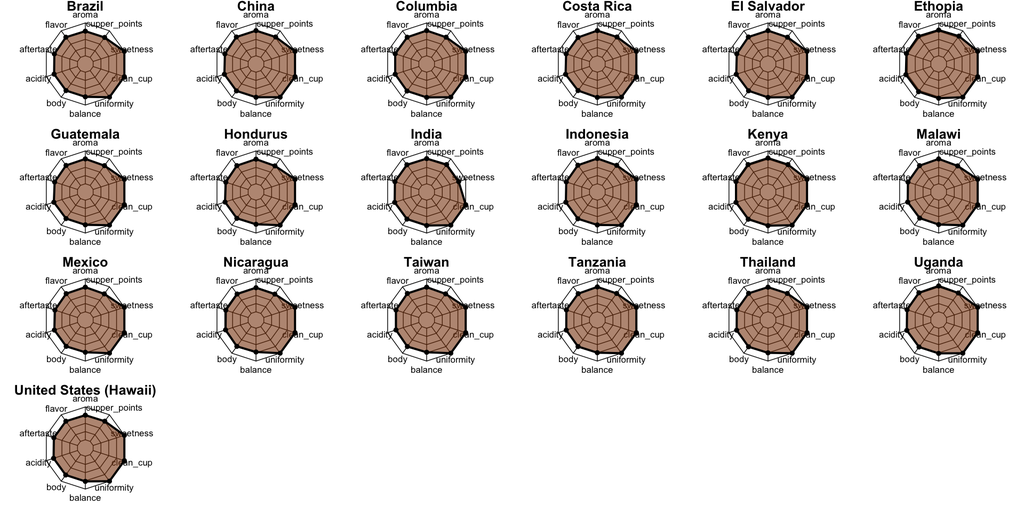

As observed in the radarcharts above, coffee profiles (depicted by the radar chart’s shape) across countries appear very similar!  
It is hard to tell for example Ethiopia was rated the highest across most categories.

Median scores of each category in each country were used in the plot. We also sieved out to countries with more than 10 coffee sampled.

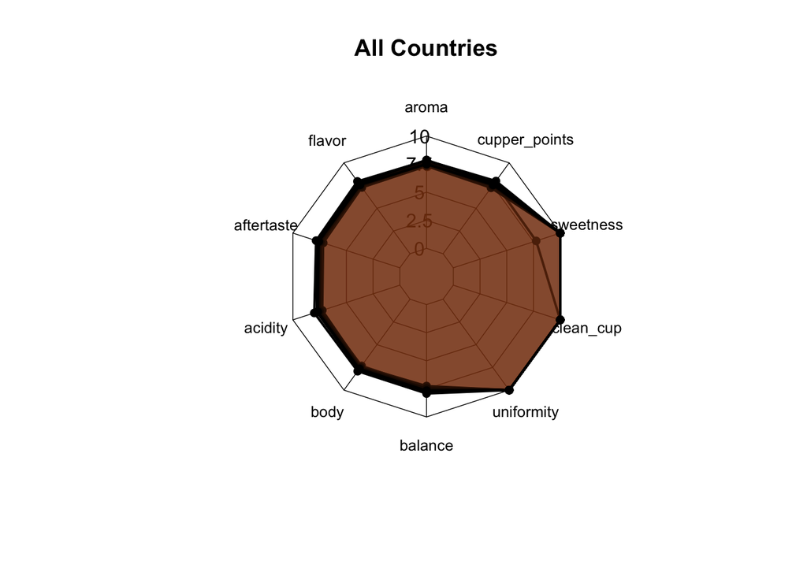

All these despite having different growing conditions such as altitude, harvesting period, types/colour of coffee beans, variety of beans etc.

# Does processing method influence coffee flavours and quality?

Next we asked ourselves: maybe processing method would make a difference?; which led us to the following analysis.

We found different [characteristics of coffee using different processing methods](https://capecoffeebeans.co.za/blogs/cape-coffee-blog/77091524-7-factors-that-influence-coffee-flavour)  
1. Washed/Wet: Tend to have higher acidity and clarity  
2. Natural/Dry: Traditional african method, tend to have fruity flavour and low acidity; Higher risk of crop spoilage.  
3. Pulped natural/Honey: Collection of wet& dry methods

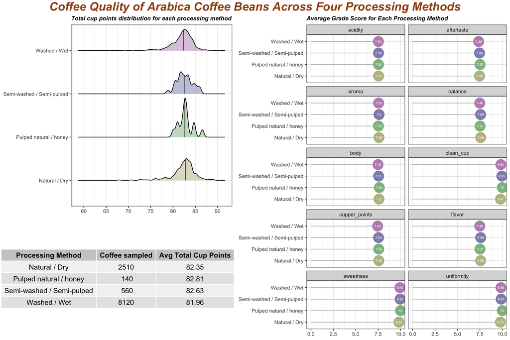

To our surprise, all processing method fared similarly! As shown on left-side figure, Washed/Wet and Natural/Dry are less erratic even though more coffee samples were carried out. All processing methods have almost equal average scores.

We then break them down into the different categories. They also achieved very similar scores in all categories!

# Conclusion

In our simple analysis, we found that coffee beans performed rather similarly regardless of different factors in growing coffee beans across countries and even processing method. The best rated coffee beans only scored better by a small margin. In other words, coffee is coffee!